# Migration 1

Plus Difference-in-Differences

Carolina Torreblanca

University of Pennsylvania

**Global Development**: Intermediate Topics in Politics, Policy, and Data

PSCI 3200 - Spring 2026

# Logistics

## Assignments

- Today
  - [Rozo and Grossman (2025)](https://voxdev.org/voxdevlit/refugees-and-other-forcibly-displaced-populations) (download the pdf and/or watch the YouTube video)
  - [Gazeaud, Jules, Eric Mvukiyehe, and Olivier Sterck (2020)](https://voxdev.org/topic/migration-urbanisation/constraints-migration-evidence-comoros)
  - [Sviatschi (2022)](https://voxdev.org/topic/migration-urbanisation/impact-us-deportation-policy-gang-activity-el-salvador)

## Agenda

1. Research Design Debrief
2. Migration
3. Causal Inference with Observational Data: Difference-in-Differences

# Research Design Debrief

## Debrief

**Submissions**

- You need to *check* what you send me…
- Read the basic instructions (quarto + html file)
- I didn’t penalize anyone, but next time I will

**Research Designs**

- Justify your sample
- Just “controlling for observables” will not get you full credit
- Next week, we’ll cover essentials… bring your questions!

# Migration Overview

## Overview of International Migration

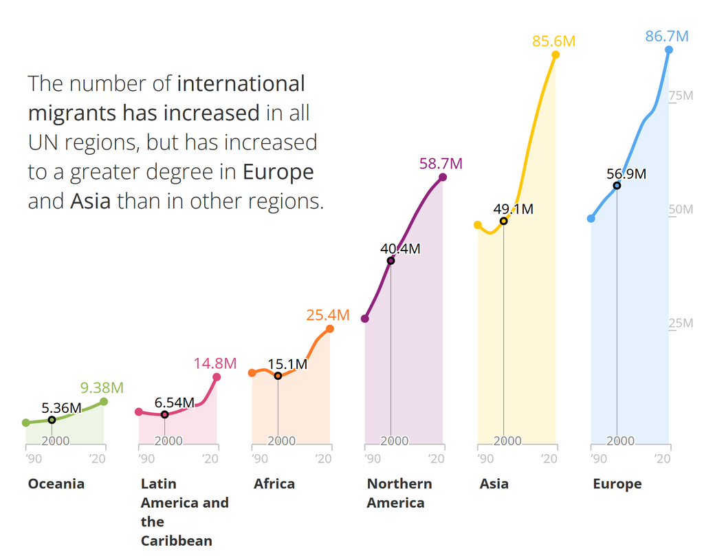

## Economic Equilibrium

- Push factors
- Pull factors
- Costs

## Economic Equilibrium: Push

**Push factors: origin country factors that affect the well-being**

- Demographics: youth bulge
- Living standards: poor infrastructure, crime
- Economic opportunities: unemployment
- Politics: exclusion

## Economic Equilibrium: Pull

**Pull factors: destination country factors that affect expected well-being**

- Demographics: aging population
- Living standards: good infrastructure, security
- Economic opportunities: labor demand, credit
- Politics: inclusion

## Economic Equilibrium: Costs

**Costs: factors that shape the costs of migrating**

- Legal restrictions
- Transportation
- Asset mobility

## Economic Equilibrium Perspective

- Migration decisions are based on expected return
- Movements from poorer to richer regions will equalize wages

## Migration Systems

**Macro linkages between sending and receiving countries**

- Migration is driven by prior links between sending and receiving countries
  - Colonization, political or cultural influence, trade, language

**Micro linkages between households**

- Migration is driven by prior links between individuals and households
  - Social ties to households in the destination country

# Rozo & Grossman

## Quiz

**5 minutes: send me a Slack DM with something you learned from this article**

## Trends: Displacement

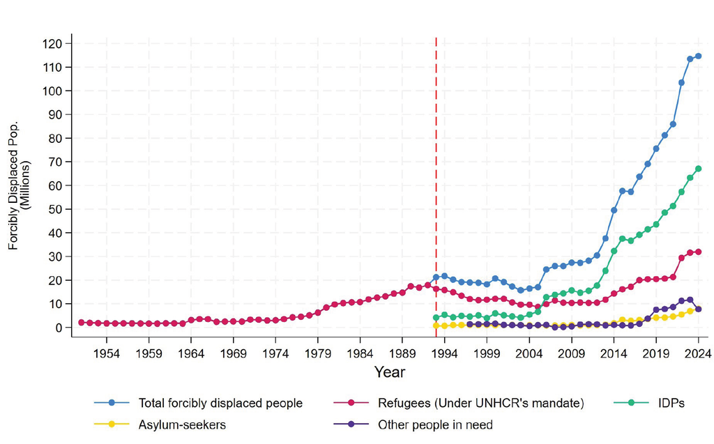

## Trends: Displacement

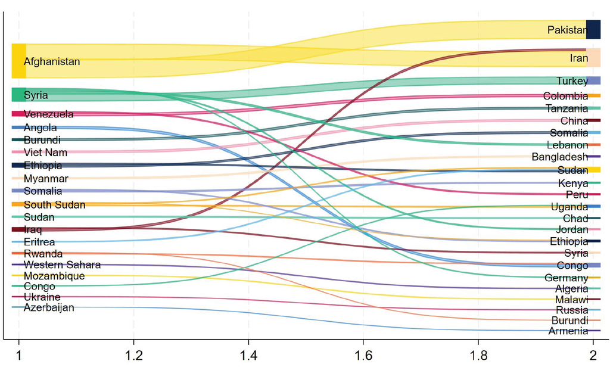

## Trends: Conflict

- War deaths continue to decline
- Interstate wars are rare by historical standards
- Geopolitical tensions are increasing
- Number, intensity, complexity, and duration of civil wars are increasing

## Trends: Conflict

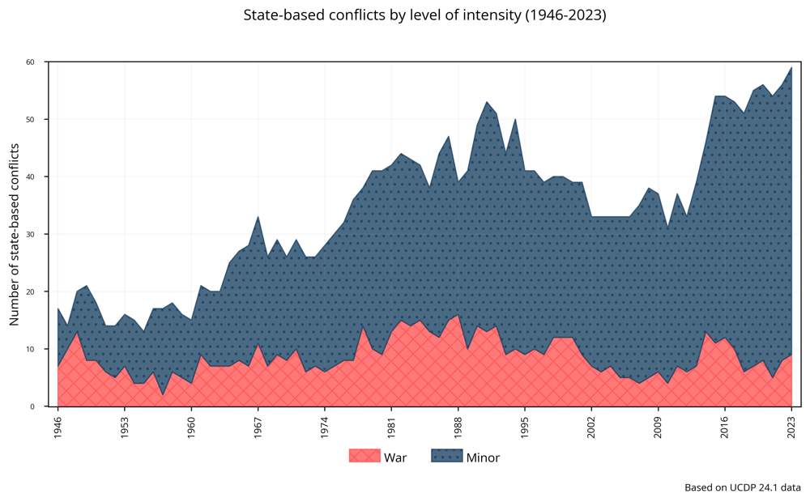

## Trends: Climate

- 78% of global land area has become drier over the past 30 years
- Warmer temperatures are causing extreme weather events

## Trends: Research

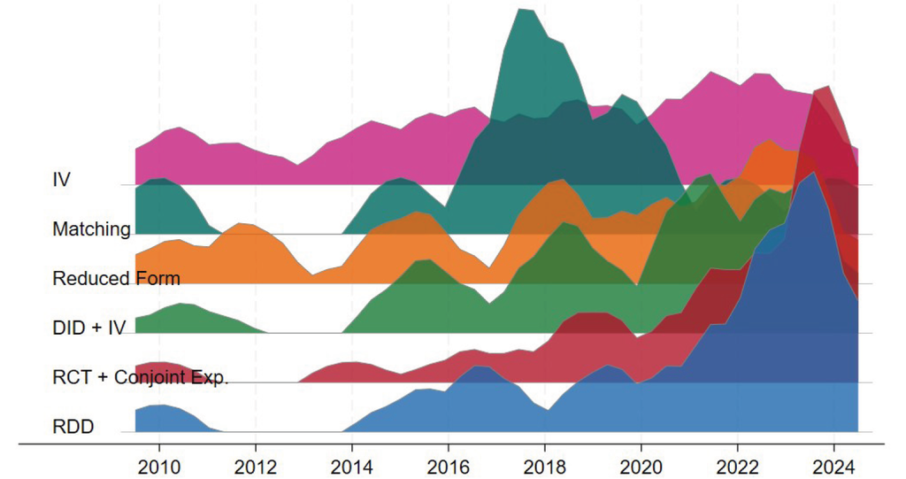

## Trends: Research

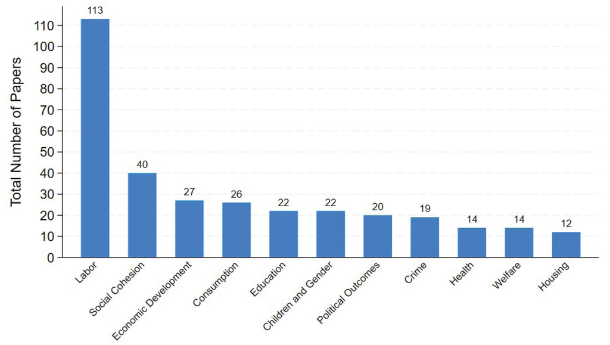

## Impact on Host: Labor markets

- Who gets hurt?
- Who benefits?
- Net effects effects?
  - Short-term challenges
  - Long-term growth

## Impact on Host: Other

- Service provision
  - Displacement effects (public to private)
  - Disease burden
- Politics
  - Wealth
  - Prior exposure

## Supporting Migrants

**Unique challenges for forced migrants?**

- Loss of assets
- Trauma and mental health
- Legal uncertainty
- Language and cultural barriers

## Supporting Migrants

**Cash transfers**

- Short-term increases in consumption, well-being

**Labor market integration**

- Increased consumption, well-being
- Reduced crime, fertility
- Kakuma vs Kalobeyei; Uganda business mentors

## Supporting Migrants

- Mental health
- Social cohesion
  - Teacher bias
  - Shared aid + integration policies
  - Perspective-taking, contact

## Policy Implications

- Shift from humanitarian response to self-reliance
- Allow hosts to benefit from aid
- Increase labor market integration
- Address discrimination and mental health

# Gazeaud et al. (2023)

## Constraints to migration

- Migration causes huge income gains
- Desire for migration is extremely high
- Actual migration flows are relatively small
- Why?

## Intervention

**Conditional cash transfer**

- Cash payment for labor on public works

Mechanisms:

1. Liquidity
2. Opportunity cost
3. Collateral and access to credit
4. Risk-aversion

## Findings

- Treatment households 38% more likely to migrate
- How did they measure spillovers?
- Mechanisms:
  - What were the mechanisms at play?
  - How did they reach these conclusions?

## Findings

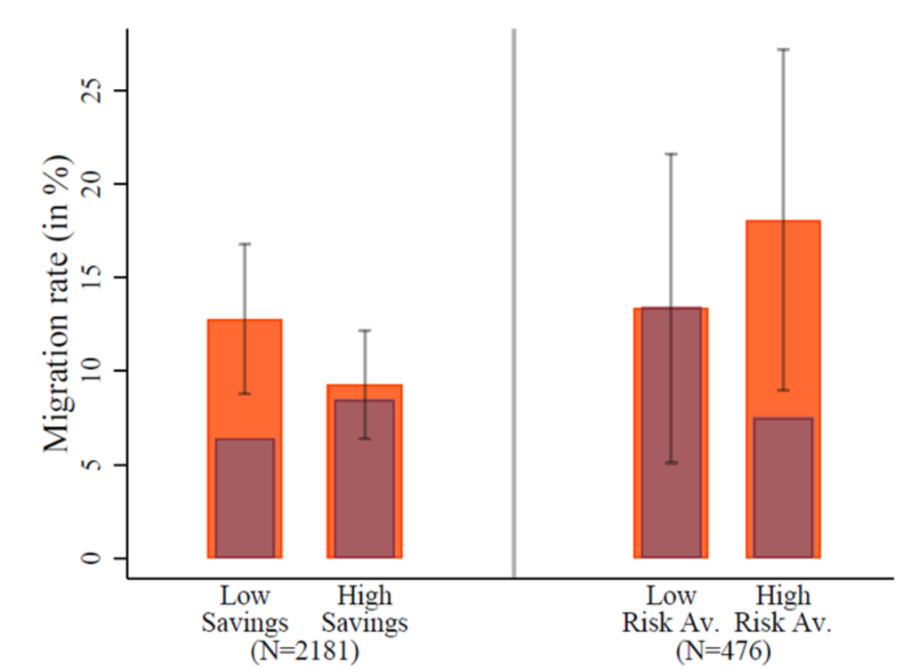

## Policy Implications

**How does this relate to the equilibrium model?**

**Policy implications**

- The poorest individuals in sending countries are not the most likely to migrate ([Clements and Mendola, 2020](https://www.cgdev.org/publication/migration-developing-countries-selection-income-elasticity-and-simpsons-paradox))
- Improving welfare in sending countries will not necessarily reduce desire to migrate
- Networks may be less influential (over short time periods and with large pre-treatment migration)

# Difference-in Differences

## Review

- What is an interaction term?
- What are fixed effects?
- Why do we like randomization?

## Identification strategy

**In the real world, there are always confounders that we can’t observe (measure) or adjust for**

- A *research design* that allows us to isolate a causal effect from observational data
- Approximates an experiment by ensuring that the treatment and untreated (control) group are similar
- These strategies rely on assumptions that we can *attempt* to validate

## Holy Trinity of Causal Inference

1. **Difference-in-Differences**
2. Regression Discontinuity
3. Instrumental Variables

## Difference-in-Differences

$$Y_{it} = \alpha + \beta_1 \text{Treatment}_i + \beta_2 \text{Post}_t + \gamma (\text{Treatment}_i \times \text{Post}_t) + \epsilon_{it}$$

- $\gamma (\text{Treatment}_i \times \text{Post}_t)$
- Assumes measurement at two points in time

## Simulation Example

```r
# Load required libraries
library(dplyr)
library(modelsummary)

# Generate example data
set.seed(123)
data <- data.frame(
  treatment = rep(c(1, 0), each = 100),
  post = rep(c(1, 0), each = 50, times = 2),
  outcome = c(rnorm(50, mean = 10, sd = 4), # control: pre-treatment
              rnorm(50, mean = 10, sd = 4), # control: post-treatment
              rnorm(50, mean = 10, sd = 4), # treatment: pre-treatment
              rnorm(50, mean = 12, sd = 4)) # treatment: post-treatment
)

head(data)
```

```
  treatment post   outcome
1         1    1  7.758097
2         1    1  9.079290
3         1    1 16.234833
4         1    1 10.282034
5         1    1 10.517151
6         1    1 16.860260
```

## Simulation Example

```r
# Summarize the output
modelsummary(
  list(lm(outcome ~ treatment + post, data = data),# standard model
       lm(outcome ~ treatment * post, data = data)), # difference-in-differences model
  estimate  = "{estimate}{stars} ({std.error})",
             statistic = NULL,
  gof_omit = 'IC|RMSE|Log|F|R2$|Std.')
```

[output not shown]

## Why can’t we just observe how units change over time?

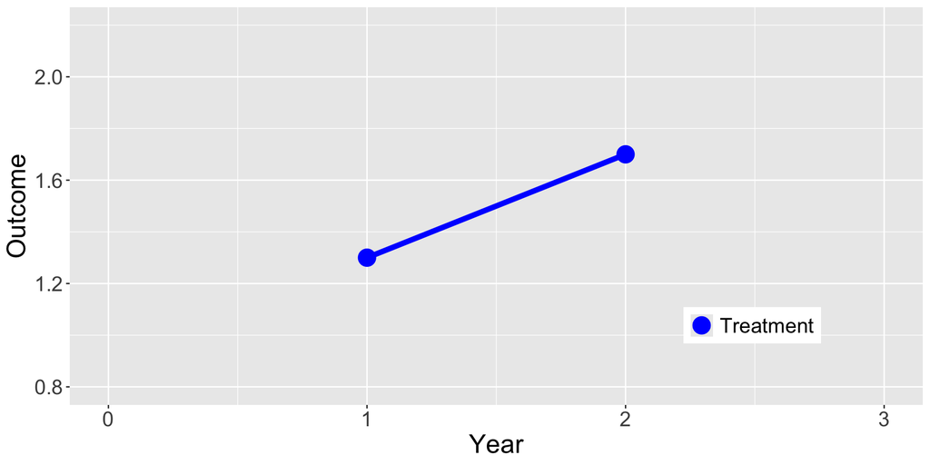

```r
library(ggplot2)

Year = c(0,1,2,3)
Outcome = c(NA, 1.3, 1.7, NA)
Treatment = c("Treatment", "Treatment","Treatment","Treatment")

dat = data.frame(Year, Outcome, Treatment)

ggplot(data = dat, aes(x = Year, y = Outcome, group = Treatment, color = Treatment)) +
  geom_line(aes(linetype=Treatment),size=2) +
  geom_point(size = 6) +
  xlim(0,3) +
  ylim(0.8, 2.2) +
  scale_linetype_manual(values=c("solid", "solid")) +
  scale_color_manual(values = c("blue") ) +
  theme(legend.position = c(0.8, 0.2), text = element_text(size=20),
        legend.title=element_blank())
```

## Why can’t we just observe how units change over time?

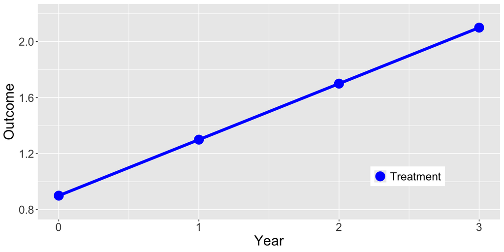

```r
Year = c(0,1,2,3)
Outcome = c(0.9, 1.3, 1.7, 2.1)
Treatment = c("Treatment", "Treatment","Treatment","Treatment")

dat = data.frame(Year, Outcome, Treatment)

ggplot(data = dat, aes(x = Year, y = Outcome, group = Treatment, color = Treatment)) +
  geom_line(aes(linetype=Treatment),size=2) +
  geom_point(size = 6) +
  xlim(0,3) +
  ylim(0.8, 2.2) +
  scale_linetype_manual(values=c("solid", "solid")) +
  scale_color_manual(values = c("blue") ) +
  theme(legend.position = c(0.8, 0.2), text = element_text(size=20),
        legend.title=element_blank())
```

## Why can’t we just compare units without randomization?

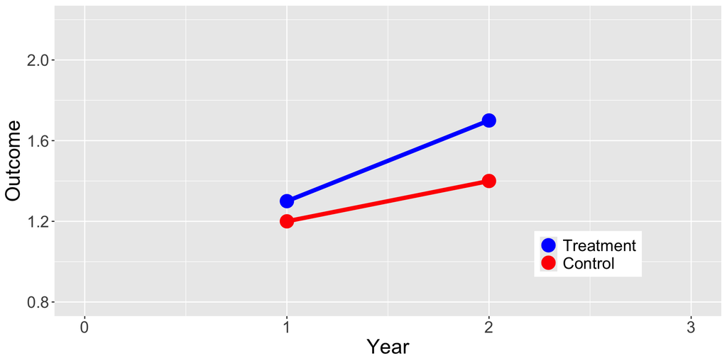

```r
Year = c(0,1,2,3)
Outcome = c(NA, 1.2, 1.4, NA,
            NA, 1.3, 1.7, NA)
Treatment = c("Control", "Control","Control","Control",
              "Treatment", "Treatment", "Treatment", "Treatment")

dat = data.frame(Year, Outcome, Treatment)
dat$Treatment = factor(dat$Treatment, levels = c("Treatment", "Control"))

ggplot(data = dat, aes(x = Year, y = Outcome, group = Treatment, color = Treatment)) +
  geom_line(aes(linetype=Treatment),size=2) +
  geom_point(size = 6) +
  xlim(0,3) +
  ylim(0.8, 2.2) +
  scale_linetype_manual(values=c("solid", "solid")) +
  scale_color_manual(values = c("blue", "red") ) +
  theme(legend.position = c(0.8, 0.2), text = element_text(size=20),
        legend.title=element_blank())
```

## Why can’t we just compare units without randomization?

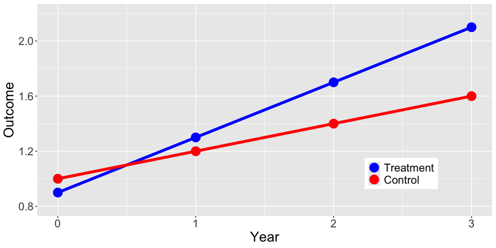

```r
Year = c(0,1,2,3)
Outcome = c(1, 1.2, 1.4, 1.6,
            0.9, 1.3, 1.7, 2.1)
Treatment = c("Control", "Control","Control","Control",
              "Treatment", "Treatment", "Treatment", "Treatment")

dat = data.frame(Year, Outcome, Treatment)
dat$Treatment = factor(dat$Treatment, levels = c("Treatment", "Control"))


ggplot(data = dat, aes(x = Year, y = Outcome, group = Treatment, color = Treatment)) +
  geom_line(aes(linetype=Treatment),size=2) +
  geom_point(size = 6) +
  xlim(0,3) +
  ylim(0.8, 2.2) +
  scale_linetype_manual(values=c("solid", "solid")) +
  scale_color_manual(values = c("blue", "red") ) +
  theme(legend.position = c(0.8, 0.2), text = element_text(size=20),
        legend.title=element_blank())
```

## Why can’t we just compare units without randomization?

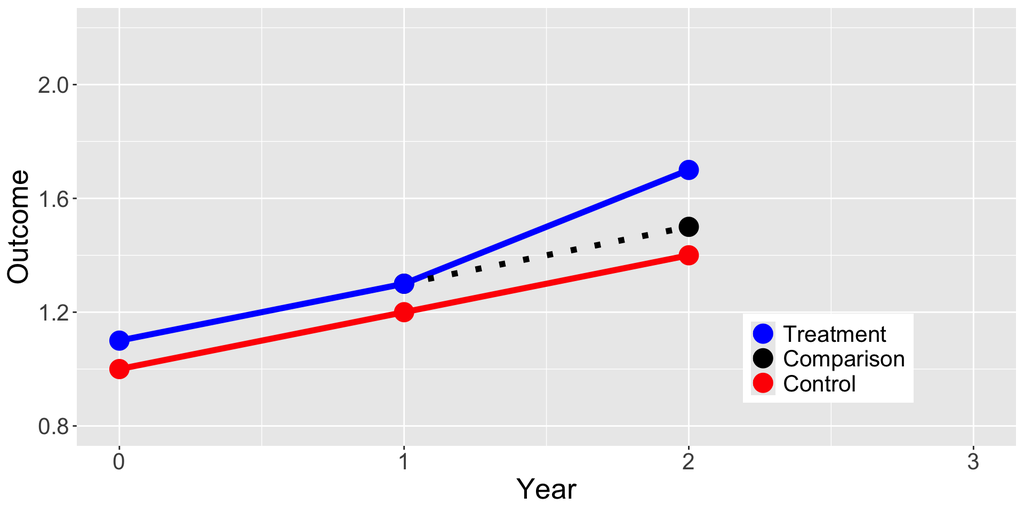

```r
Year = c(0,1,2,3)
Outcome = c(NA, 1.3, 1.5, NA,
            1, 1.2, 1.4, NA,
            1.1, 1.3, 1.7, NA)
Treatment = c("Comparison","Comparison","Comparison","Comparison",
              "Control", "Control","Control","Control",
              "Treatment", "Treatment", "Treatment", "Treatment")

dat = data.frame(Year, Outcome, Treatment)
dat$Treatment = factor(dat$Treatment, levels = c("Treatment", "Comparison", "Control"))

ggplot(data = dat, aes(x = Year, y = Outcome,  color = Treatment)) +
  geom_line(aes(linetype=Treatment),size=2) +
  geom_point(size = 6) +
  ylim(0.8, 2.2) +
  scale_linetype_manual(values=c("solid", "dotted", "solid")) +
  scale_color_manual(values = c("blue", "black", "red"  ) ) +
  theme(legend.position = c(0.8, 0.2), text = element_text(size=20),
        legend.title=element_blank())
```

## Why can’t we just compare units without randomization?

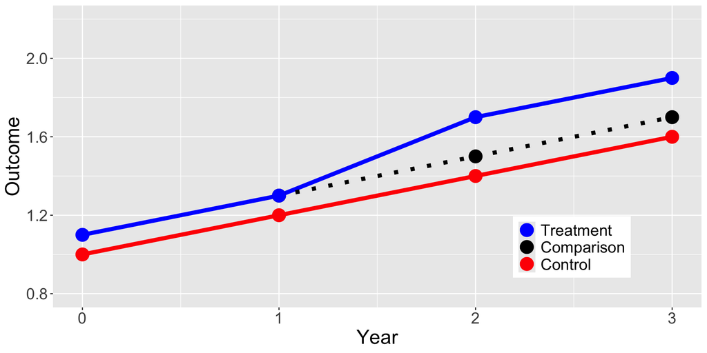

```r
Year = c(0,1,2,3)
Outcome = c(NA, 1.3, 1.5, 1.7,
            1, 1.2, 1.4,1.6,
            1.1, 1.3, 1.7, 1.9)
Treatment = c("Comparison","Comparison","Comparison","Comparison",
              "Control", "Control","Control","Control",
              "Treatment", "Treatment", "Treatment", "Treatment")

dat = data.frame(Year, Outcome, Treatment)
dat$Treatment = factor(dat$Treatment, levels = c("Treatment", "Comparison", "Control"))

ggplot(data = dat, aes(x = Year, y = Outcome,  color = Treatment)) +
  geom_line(aes(linetype=Treatment),size=2) +
  geom_point(size = 6) +
  ylim(0.8, 2.2) +
  scale_linetype_manual(values=c("solid", "dotted", "solid")) +
  scale_color_manual(values = c("blue", "black", "red"  ) ) +
  theme(legend.position = c(0.8, 0.2), text = element_text(size=20),
        legend.title=element_blank())
```

# Sviatschi (2022)

## Sviatschi (2022)

- What is the effect of mass deportations on the root causes of migration?

## Three sources of variation

1. Geography (birth municipality)
2. Time (policy change)
3. Age (recruitment age)

## Identifying assumption

- Municipalities where gang-deportees were born would have changed in similar ways to other municipalities *in the absence of a policy change*

## Findings

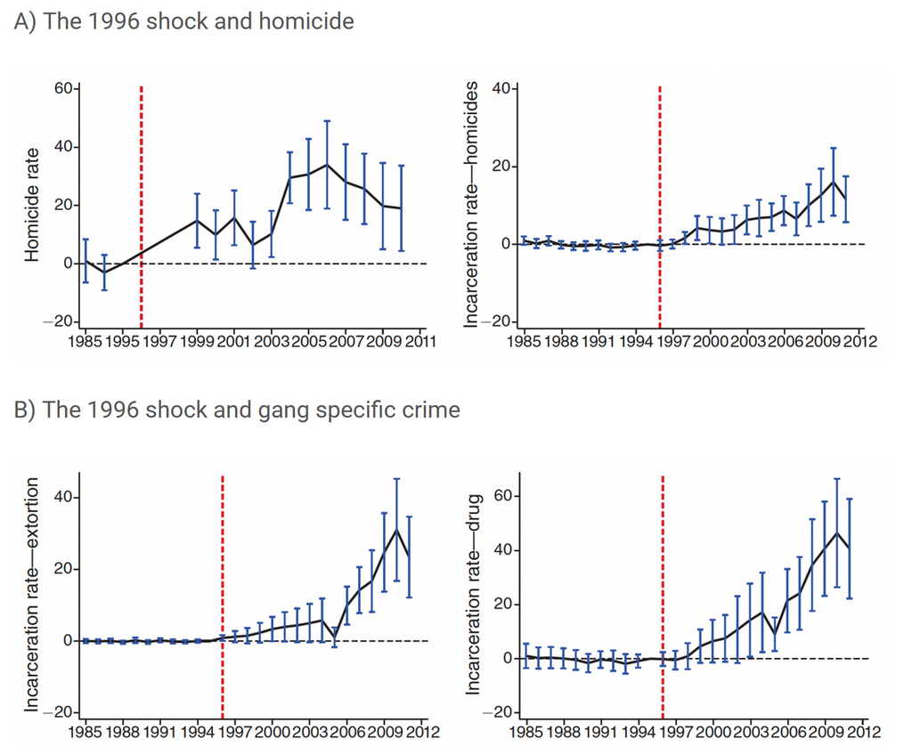

## Policy Implications

- Addressing pull factors can have unintended affects on push factors in complex ways

## Threats to Inference

- Confounders
- Colliders
- Mechanisms
- Reverse Causality

## Adjusting on Observables

- Matching
- Weighting
- Synthetic Control (very fancy weighting)

## Validity

- Internal validity
- External validity
- What are the trade-offs between experiments and observational studies?
  - Experiments have more internal validity
  - But… they often have synthetic treatments, convenience samples
- Where are these studies used in the real-world?

# 3ie Evidence Review

## Irregular Migration Evidence Review

**Objective:**

- Review evidence efficacy of interventions designed to target the root causes of irregular migration

**Root causes: social and political conditions that induce departures**

1. Lack of economic opportunity
2. Lack of capacity to adopt to shocks
3. High levels of violence
4. Lack of regular migration channels

## Irregular Migration Evidence Review

**What is irregular migration?**

- Migration outside legal channels

**Why is it different from regular migration?**

- Additional risks relative to legal migration (violence, exploitation, access to legal system)

## Findings

Studies reporting migration outcomes are concentrated on 3 intervention categories:

1. Human capital strengthening
2. Active labor market policies
3. Information campaigns

## Conclusions

- Some evidence on interventions that address the root causes of irregular migration
- Almost no evidence looking at irregular migration as a primary outcome
- A number of studies are ongoing

https://carolina-torreblanca.github.io/psci3200-globaldev-main/